# Risk Factor Analysis

## Outcome Variable

**Outcome Variable:** haz

## Predictor Variables

**Intervention Variable:** exclfeed3

**Adjustment Set:**

- arm
- sex
- brthmon
- W_mage
- meducyrs
- feducyrs
- hhwealth_quart
- hfoodsec
- W_mhtcm
- W_mwtkg
- W_mbmi
- vagbrth
- W_gagebrth
- W_birthwt
- W_birthlen
- W_nrooms
- W_nchldlt5
- month
- W_parity
- impfloor
- impsan
- safeh20
- delta_W_mage
- delta_meducyrs
- delta_feducyrs
- delta_hhwealth_quart
- delta_hfoodsec
- delta_W_mhtcm
- delta_W_mwtkg
- delta_W_mbmi
- delta_vagbrth
- delta_W_gagebrth
- delta_W_birthwt
- delta_W_birthlen
- delta_W_nrooms
- delta_W_nchldlt5
- delta_month
- delta_W_parity
- delta_impfloor
- delta_impsan
- delta_safeh20

## Stratifying Variables

The analysis was stratified on these variable(s):

- agecat
- studyid
- country

## Data Summary

| agecat | studyid | country | exclfeed3 | n_cell | n | outcome_variable |
| --- | --- | --- | --- | --- | --- | --- |
| Birth | CMC-V-BCS-2002 | INDIA | 1 | 4 | 4 | haz |
| Birth | CMC-V-BCS-2002 | INDIA | 0 | 0 | 4 | haz |
| Birth | EE | PAKISTAN | 1 | 35 | 35 | haz |
| Birth | EE | PAKISTAN | 0 | 0 | 35 | haz |
| Birth | GMS-Nepal | NEPAL | 1 | 380 | 458 | haz |
| Birth | GMS-Nepal | NEPAL | 0 | 78 | 458 | haz |
| Birth | IRC | INDIA | 1 | 0 | 10 | haz |
| Birth | IRC | INDIA | 0 | 10 | 10 | haz |
| Birth | JiVitA-3 | BANGLADESH | 1 | 12014 | 13276 | haz |
| Birth | JiVitA-3 | BANGLADESH | 0 | 1262 | 13276 | haz |
| Birth | JiVitA-4 | BANGLADESH | 1 | 105 | 116 | haz |
| Birth | JiVitA-4 | BANGLADESH | 0 | 11 | 116 | haz |
| Birth | Keneba | GAMBIA | 1 | 1198 | 1356 | haz |
| Birth | Keneba | GAMBIA | 0 | 158 | 1356 | haz |
| Birth | MAL-ED | BANGLADESH | 1 | 138 | 215 | haz |
| Birth | MAL-ED | BANGLADESH | 0 | 77 | 215 | haz |
| Birth | MAL-ED | BRAZIL | 1 | 12 | 57 | haz |
| Birth | MAL-ED | BRAZIL | 0 | 45 | 57 | haz |
| Birth | MAL-ED | INDIA | 1 | 24 | 41 | haz |
| Birth | MAL-ED | INDIA | 0 | 17 | 41 | haz |
| Birth | MAL-ED | NEPAL | 1 | 8 | 26 | haz |
| Birth | MAL-ED | NEPAL | 0 | 18 | 26 | haz |
| Birth | MAL-ED | PERU | 1 | 49 | 223 | haz |
| Birth | MAL-ED | PERU | 0 | 174 | 223 | haz |
| Birth | MAL-ED | SOUTH AFRICA | 1 | 12 | 100 | haz |
| Birth | MAL-ED | SOUTH AFRICA | 0 | 88 | 100 | haz |
| Birth | MAL-ED | TANZANIA, UNITED REPUBLIC OF | 1 | 17 | 102 | haz |
| Birth | MAL-ED | TANZANIA, UNITED REPUBLIC OF | 0 | 85 | 102 | haz |
| Birth | PROVIDE | BANGLADESH | 1 | 387 | 539 | haz |
| Birth | PROVIDE | BANGLADESH | 0 | 152 | 539 | haz |

[output cut: 64 more lines]

The following strata were considered:

- agecat: 24 months, studyid: CMC-V-BCS-2002, country: INDIA
- agecat: 24 months, studyid: EE, country: PAKISTAN
- agecat: 24 months, studyid: GMS-Nepal, country: NEPAL
- agecat: 24 months, studyid: IRC, country: INDIA
- agecat: 24 months, studyid: JiVitA-3, country: BANGLADESH
- agecat: 24 months, studyid: JiVitA-4, country: BANGLADESH
- agecat: 24 months, studyid: Keneba, country: GAMBIA
- agecat: 24 months, studyid: MAL-ED, country: BANGLADESH
- agecat: 24 months, studyid: MAL-ED, country: BRAZIL
- agecat: 24 months, studyid: MAL-ED, country: INDIA
- agecat: 24 months, studyid: MAL-ED, country: NEPAL
- agecat: 24 months, studyid: MAL-ED, country: PERU
- agecat: 24 months, studyid: MAL-ED, country: SOUTH AFRICA
- agecat: 24 months, studyid: MAL-ED, country: TANZANIA, UNITED REPUBLIC OF
- agecat: 24 months, studyid: PROVIDE, country: BANGLADESH
- agecat: 6 months, studyid: CMC-V-BCS-2002, country: INDIA
- agecat: 6 months, studyid: EE, country: PAKISTAN
- agecat: 6 months, studyid: GMS-Nepal, country: NEPAL
- agecat: 6 months, studyid: IRC, country: INDIA
- agecat: 6 months, studyid: JiVitA-3, country: BANGLADESH
- agecat: 6 months, studyid: JiVitA-4, country: BANGLADESH
- agecat: 6 months, studyid: Keneba, country: GAMBIA
- agecat: 6 months, studyid: MAL-ED, country: BANGLADESH
- agecat: 6 months, studyid: MAL-ED, country: BRAZIL
- agecat: 6 months, studyid: MAL-ED, country: INDIA
- agecat: 6 months, studyid: MAL-ED, country: NEPAL
- agecat: 6 months, studyid: MAL-ED, country: PERU
- agecat: 6 months, studyid: MAL-ED, country: SOUTH AFRICA
- agecat: 6 months, studyid: MAL-ED, country: TANZANIA, UNITED REPUBLIC OF
- agecat: 6 months, studyid: PROVIDE, country: BANGLADESH
- agecat: 6 months, studyid: SAS-CompFeed, country: INDIA
- agecat: Birth, studyid: CMC-V-BCS-2002, country: INDIA
- agecat: Birth, studyid: EE, country: PAKISTAN
- agecat: Birth, studyid: GMS-Nepal, country: NEPAL
- agecat: Birth, studyid: IRC, country: INDIA
- agecat: Birth, studyid: JiVitA-3, country: BANGLADESH
- agecat: Birth, studyid: JiVitA-4, country: BANGLADESH
- agecat: Birth, studyid: Keneba, country: GAMBIA
- agecat: Birth, studyid: MAL-ED, country: BANGLADESH
- agecat: Birth, studyid: MAL-ED, country: BRAZIL
- agecat: Birth, studyid: MAL-ED, country: INDIA
- agecat: Birth, studyid: MAL-ED, country: NEPAL
- agecat: Birth, studyid: MAL-ED, country: PERU
- agecat: Birth, studyid: MAL-ED, country: SOUTH AFRICA
- agecat: Birth, studyid: MAL-ED, country: TANZANIA, UNITED REPUBLIC OF
- agecat: Birth, studyid: PROVIDE, country: BANGLADESH
- agecat: Birth, studyid: SAS-CompFeed, country: INDIA

### Dropped Strata

Some strata were dropped due to rare outcomes:

- agecat: Birth, studyid: CMC-V-BCS-2002, country: INDIA
- agecat: Birth, studyid: EE, country: PAKISTAN
- agecat: Birth, studyid: IRC, country: INDIA
- agecat: 6 months, studyid: CMC-V-BCS-2002, country: INDIA
- agecat: 6 months, studyid: EE, country: PAKISTAN
- agecat: 6 months, studyid: IRC, country: INDIA
- agecat: 24 months, studyid: CMC-V-BCS-2002, country: INDIA
- agecat: 24 months, studyid: EE, country: PAKISTAN
- agecat: 24 months, studyid: IRC, country: INDIA

## Methods Detail

We’re interested in the causal parameters $E[Y_a]$ for all values of $a \in \mathcal{A}$. These parameters represent the mean outcome if, possibly contrary to fact, we intervened to set all units to have $A=a$. Under the randomization and positivity assumptions, these are identified by the statistical parameters $\psi_a=E_W[E_{Y|A,W}(Y|A=a,W)]$. In addition, we’re interested in the mean of $Y$, $E[Y]$ under no intervention (the observed mean). We will estimate these parameters by using SuperLearner to fit the relevant likelihood factors – $E_{Y|A,W}(Y|A=a,W)$ and $p(A=a|W)$, and then updating our likelihood fit using a joint TMLE.

For unadjusted analyses ($W=\{\}$), initial likelihoods were estimated using Lrnr_glm to estimate the simple $E(Y|A)$ and Lrnr_mean to estimate $p(A)$. For adjusted analyses, a small library containing Lrnr_glmnet, Lrnr_xgboost, and Lrnr_mean was used.

Having estimated these parameters, we will then use the delta method to estimate relative risks and attributable risks relative to a prespecified baseline level of $A$.

# Results Detail

## Results Plots

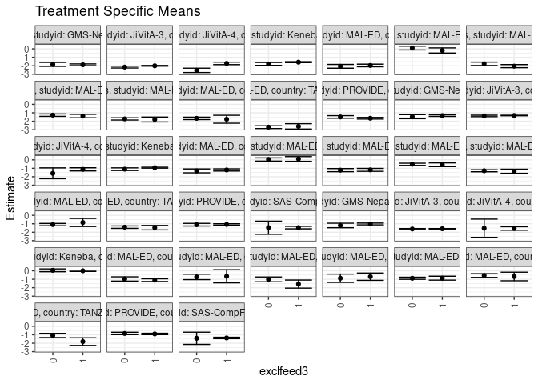

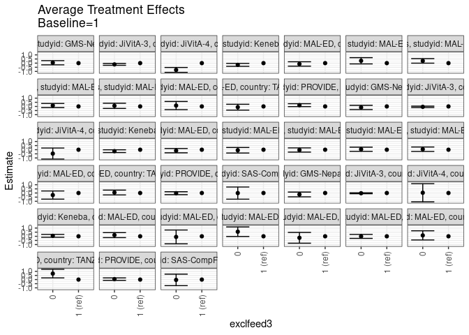

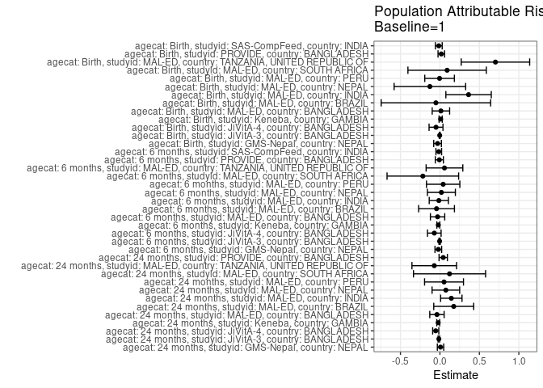

## Results Table

### Parameter: TSM

| agecat | studyid | country | intervention_level | baseline_level | estimate | ci_lower | ci_upper |
| --- | --- | --- | --- | --- | --- | --- | --- |
| Birth | GMS-Nepal | NEPAL | 1 | NA | -1.0254653 | -1.1324664 | -0.9184641 |
| Birth | GMS-Nepal | NEPAL | 0 | NA | -1.2005179 | -1.4677674 | -0.9332684 |
| Birth | JiVitA-3 | BANGLADESH | 1 | NA | -1.5899020 | -1.6135434 | -1.5662606 |
| Birth | JiVitA-3 | BANGLADESH | 0 | NA | -1.6190831 | -1.6742452 | -1.5639210 |
| Birth | JiVitA-4 | BANGLADESH | 1 | NA | -1.5578127 | -1.7633388 | -1.3522867 |
| Birth | JiVitA-4 | BANGLADESH | 0 | NA | -1.5278897 | -2.6062732 | -0.4495062 |
| Birth | Keneba | GAMBIA | 1 | NA | 0.0004887 | -0.0726591 | 0.0736364 |
| Birth | Keneba | GAMBIA | 0 | NA | 0.0560739 | -0.1101861 | 0.2223339 |
| Birth | MAL-ED | BANGLADESH | 1 | NA | -1.1074966 | -1.2690657 | -0.9459275 |
| Birth | MAL-ED | BANGLADESH | 0 | NA | -0.9634474 | -1.2159692 | -0.7109256 |
| Birth | MAL-ED | BRAZIL | 1 | NA | -0.6486454 | -1.4248289 | 0.1275381 |
| Birth | MAL-ED | BRAZIL | 0 | NA | -0.7245356 | -1.0466266 | -0.4024445 |
| Birth | MAL-ED | INDIA | 1 | NA | -1.5705425 | -2.0480390 | -1.0930460 |
| Birth | MAL-ED | INDIA | 0 | NA | -1.0155999 | -1.3015352 | -0.7296646 |
| Birth | MAL-ED | NEPAL | 1 | NA | -0.6962500 | -1.1273498 | -0.2651502 |
| Birth | MAL-ED | NEPAL | 0 | NA | -0.8800000 | -1.3706027 | -0.3893973 |
| Birth | MAL-ED | PERU | 1 | NA | -0.8707978 | -1.1024293 | -0.6391663 |
| Birth | MAL-ED | PERU | 0 | NA | -0.8821947 | -1.0054355 | -0.7589539 |
| Birth | MAL-ED | SOUTH AFRICA | 1 | NA | -0.6708026 | -1.1795795 | -0.1620256 |
| Birth | MAL-ED | SOUTH AFRICA | 0 | NA | -0.5618227 | -0.7803952 | -0.3432503 |
| Birth | MAL-ED | TANZANIA, UNITED REPUBLIC OF | 1 | NA | -1.8121562 | -2.2649020 | -1.3594103 |
| Birth | MAL-ED | TANZANIA, UNITED REPUBLIC OF | 0 | NA | -1.0863085 | -1.3339865 | -0.8386305 |
| Birth | PROVIDE | BANGLADESH | 1 | NA | -0.9027179 | -0.9831410 | -0.8222948 |
| Birth | PROVIDE | BANGLADESH | 0 | NA | -0.8477029 | -0.9884190 | -0.7069868 |
| Birth | SAS-CompFeed | INDIA | 1 | NA | -1.3791852 | -1.4632653 | -1.2951052 |
| Birth | SAS-CompFeed | INDIA | 0 | NA | -1.4188476 | -2.1434587 | -0.6942365 |
| 6 months | GMS-Nepal | NEPAL | 1 | NA | -1.3295864 | -1.4243040 | -1.2348687 |
| 6 months | GMS-Nepal | NEPAL | 0 | NA | -1.4541726 | -1.6928368 | -1.2155085 |
| 6 months | JiVitA-3 | BANGLADESH | 1 | NA | -1.3197618 | -1.3489334 | -1.2905901 |
| 6 months | JiVitA-3 | BANGLADESH | 0 | NA | -1.3701438 | -1.4557450 | -1.2845425 |
| 6 months | JiVitA-4 | BANGLADESH | 1 | NA | -1.1281066 | -1.3156615 | -0.9405516 |
| 6 months | JiVitA-4 | BANGLADESH | 0 | NA | -1.5954844 | -2.2383720 | -0.9525968 |
| 6 months | Keneba | GAMBIA | 1 | NA | -0.9285895 | -0.9825747 | -0.8746043 |
| 6 months | Keneba | GAMBIA | 0 | NA | -1.1047992 | -1.2612534 | -0.9483449 |
| 6 months | MAL-ED | BANGLADESH | 1 | NA | -1.1943934 | -1.3256548 | -1.0631319 |
| 6 months | MAL-ED | BANGLADESH | 0 | NA | -1.3081145 | -1.5378949 | -1.0783340 |
| 6 months | MAL-ED | BRAZIL | 1 | NA | 0.1039324 | -0.1728775 | 0.3807423 |
| 6 months | MAL-ED | BRAZIL | 0 | NA | 0.0399114 | -0.1472115 | 0.2270344 |
| 6 months | MAL-ED | INDIA | 1 | NA | -1.1861294 | -1.3608864 | -1.0113724 |
| 6 months | MAL-ED | INDIA | 0 | NA | -1.2199359 | -1.4057566 | -1.0341152 |
| 6 months | MAL-ED | NEPAL | 1 | NA | -0.5819767 | -0.8030324 | -0.3609209 |
| 6 months | MAL-ED | NEPAL | 0 | NA | -0.5292988 | -0.6585642 | -0.4000333 |
| 6 months | MAL-ED | PERU | 1 | NA | -1.3518723 | -1.5941021 | -1.1096424 |
| 6 months | MAL-ED | PERU | 0 | NA | -1.2935139 | -1.4144584 | -1.1725694 |
| 6 months | MAL-ED | SOUTH AFRICA | 1 | NA | -0.8496030 | -1.3256994 | -0.3735066 |
| 6 months | MAL-ED | SOUTH AFRICA | 0 | NA | -1.0980887 | -1.2330941 | -0.9630833 |
| 6 months | MAL-ED | TANZANIA, UNITED REPUBLIC OF | 1 | NA | -1.4605731 | -1.7216021 | -1.1995441 |
| 6 months | MAL-ED | TANZANIA, UNITED REPUBLIC OF | 0 | NA | -1.4013869 | -1.5442891 | -1.2584846 |
| 6 months | PROVIDE | BANGLADESH | 1 | NA | -1.0842039 | -1.1681563 | -1.0002514 |
| 6 months | PROVIDE | BANGLADESH | 0 | NA | -1.1085468 | -1.2650270 | -0.9520666 |
| 6 months | SAS-CompFeed | INDIA | 1 | NA | -1.4549959 | -1.6008850 | -1.3091069 |
| 6 months | SAS-CompFeed | INDIA | 0 | NA | -1.4654856 | -2.2428805 | -0.6880907 |
| 24 months | GMS-Nepal | NEPAL | 1 | NA | -1.8829028 | -1.9845584 | -1.7812473 |
| 24 months | GMS-Nepal | NEPAL | 0 | NA | -1.8353169 | -2.0680698 | -1.6025640 |
| 24 months | JiVitA-3 | BANGLADESH | 1 | NA | -2.0050497 | -2.0428321 | -1.9672673 |
| 24 months | JiVitA-3 | BANGLADESH | 0 | NA | -2.1572239 | -2.2656656 | -2.0487823 |
| 24 months | JiVitA-4 | BANGLADESH | 1 | NA | -1.7193946 | -1.8668960 | -1.5718933 |
| 24 months | JiVitA-4 | BANGLADESH | 0 | NA | -2.5418461 | -2.7961341 | -2.2875580 |
| 24 months | Keneba | GAMBIA | 1 | NA | -1.5743931 | -1.6313799 | -1.5174062 |
| 24 months | Keneba | GAMBIA | 0 | NA | -1.7834221 | -1.9540048 | -1.6128394 |
| 24 months | MAL-ED | BANGLADESH | 1 | NA | -1.9637951 | -2.1186225 | -1.8089676 |
| 24 months | MAL-ED | BANGLADESH | 0 | NA | -2.0651087 | -2.2890264 | -1.8411910 |
| 24 months | MAL-ED | BRAZIL | 1 | NA | -0.1910279 | -0.4933323 | 0.1112766 |
| 24 months | MAL-ED | BRAZIL | 0 | NA | 0.0945258 | -0.1277379 | 0.3167894 |
| 24 months | MAL-ED | INDIA | 1 | NA | -2.0438339 | -2.2285885 | -1.8590792 |
| 24 months | MAL-ED | INDIA | 0 | NA | -1.7714060 | -1.9719718 | -1.5708403 |
| 24 months | MAL-ED | NEPAL | 1 | NA | -1.3861289 | -1.5937129 | -1.1785449 |
| 24 months | MAL-ED | NEPAL | 0 | NA | -1.2757517 | -1.4202747 | -1.1312288 |
| 24 months | MAL-ED | PERU | 1 | NA | -1.7931937 | -2.0808921 | -1.5054954 |
| 24 months | MAL-ED | PERU | 0 | NA | -1.7209098 | -1.8532140 | -1.5886056 |
| 24 months | MAL-ED | SOUTH AFRICA | 1 | NA | -1.7640824 | -2.2343424 | -1.2938223 |
| 24 months | MAL-ED | SOUTH AFRICA | 0 | NA | -1.6594030 | -1.8049546 | -1.5138514 |
| 24 months | MAL-ED | TANZANIA, UNITED REPUBLIC OF | 1 | NA | -2.6049204 | -2.9184019 | -2.2914389 |
| 24 months | MAL-ED | TANZANIA, UNITED REPUBLIC OF | 0 | NA | -2.6975390 | -2.8615618 | -2.5335162 |
| 24 months | PROVIDE | BANGLADESH | 1 | NA | -1.6441034 | -1.7417051 | -1.5465016 |
| 24 months | PROVIDE | BANGLADESH | 0 | NA | -1.4909094 | -1.6431724 | -1.3386464 |

### Parameter: E(Y)

| agecat | studyid | country | intervention_level | baseline_level | estimate | ci_lower | ci_upper |
| --- | --- | --- | --- | --- | --- | --- | --- |
| Birth | GMS-Nepal | NEPAL | NA | NA | -1.0555240 | -1.1550843 | -0.9559638 |
| Birth | JiVitA-3 | BANGLADESH | NA | NA | -1.5928457 | -1.6158667 | -1.5698248 |
| Birth | JiVitA-4 | BANGLADESH | NA | NA | -1.6073276 | -1.8105798 | -1.4040753 |
| Birth | Keneba | GAMBIA | NA | NA | 0.0098304 | -0.0597854 | 0.0794461 |
| Birth | MAL-ED | BANGLADESH | NA | NA | -1.0949767 | -1.2319917 | -0.9579618 |
| Birth | MAL-ED | BRAZIL | NA | NA | -0.6996491 | -0.9856018 | -0.4136965 |
| Birth | MAL-ED | INDIA | NA | NA | -1.2075610 | -1.5261540 | -0.8889679 |
| Birth | MAL-ED | NEPAL | NA | NA | -0.8234615 | -1.1896049 | -0.4573182 |
| Birth | MAL-ED | PERU | NA | NA | -0.8753812 | -0.9932108 | -0.7575515 |
| Birth | MAL-ED | SOUTH AFRICA | NA | NA | -0.5797000 | -0.7788298 | -0.3805702 |
| Birth | MAL-ED | TANZANIA, UNITED REPUBLIC OF | NA | NA | -1.1086275 | -1.3310338 | -0.8862211 |
| Birth | PROVIDE | BANGLADESH | NA | NA | -0.8851020 | -0.9601332 | -0.8100709 |
| Birth | SAS-CompFeed | INDIA | NA | NA | -1.3937088 | -1.5095039 | -1.2779137 |
| 6 months | GMS-Nepal | NEPAL | NA | NA | -1.3499849 | -1.4387386 | -1.2612312 |
| 6 months | JiVitA-3 | BANGLADESH | NA | NA | -1.3240051 | -1.3526414 | -1.2953689 |
| 6 months | JiVitA-4 | BANGLADESH | NA | NA | -1.1994318 | -1.3808291 | -1.0180345 |
| 6 months | Keneba | GAMBIA | NA | NA | -0.9489317 | -1.0001696 | -0.8976937 |
| 6 months | MAL-ED | BANGLADESH | NA | NA | -1.2242918 | -1.3439424 | -1.1046413 |
| 6 months | MAL-ED | BRAZIL | NA | NA | 0.0609091 | -0.0944768 | 0.2162950 |
| 6 months | MAL-ED | INDIA | NA | NA | -1.2002381 | -1.3274929 | -1.0729833 |
| 6 months | MAL-ED | NEPAL | NA | NA | -0.5634068 | -0.6769687 | -0.4498449 |
| 6 months | MAL-ED | PERU | NA | NA | -1.3108735 | -1.4182407 | -1.2035062 |
| 6 months | MAL-ED | SOUTH AFRICA | NA | NA | -1.0662227 | -1.1965862 | -0.9358591 |
| 6 months | MAL-ED | TANZANIA, UNITED REPUBLIC OF | NA | NA | -1.4030503 | -1.5292443 | -1.2768563 |
| 6 months | PROVIDE | BANGLADESH | NA | NA | -1.0916915 | -1.1661176 | -1.0172654 |
| 6 months | SAS-CompFeed | INDIA | NA | NA | -1.4697236 | -1.6333919 | -1.3060553 |
| 24 months | GMS-Nepal | NEPAL | NA | NA | -1.8752995 | -1.9688053 | -1.7817937 |
| 24 months | JiVitA-3 | BANGLADESH | NA | NA | -2.0187325 | -2.0554682 | -1.9819968 |
| 24 months | JiVitA-4 | BANGLADESH | NA | NA | -1.7726490 | -1.9111913 | -1.6341067 |
| 24 months | Keneba | GAMBIA | NA | NA | -1.5961170 | -1.6505261 | -1.5417080 |
| 24 months | MAL-ED | BANGLADESH | NA | NA | -2.0016585 | -2.1303297 | -1.8729874 |
| 24 months | MAL-ED | BRAZIL | NA | NA | -0.0162939 | -0.1929098 | 0.1603221 |
| 24 months | MAL-ED | INDIA | NA | NA | -1.8994059 | -2.0346781 | -1.7641337 |
| 24 months | MAL-ED | NEPAL | NA | NA | -1.3109318 | -1.4313748 | -1.1904888 |
| 24 months | MAL-ED | PERU | NA | NA | -1.7412963 | -1.8630698 | -1.6195228 |
| 24 months | MAL-ED | SOUTH AFRICA | NA | NA | -1.6424525 | -1.7808926 | -1.5040124 |
| 24 months | MAL-ED | TANZANIA, UNITED REPUBLIC OF | NA | NA | -2.6768207 | -2.8213178 | -2.5323235 |
| 24 months | PROVIDE | BANGLADESH | NA | NA | -1.6024221 | -1.6857420 | -1.5191023 |

### Parameter: ATE

| agecat | studyid | country | intervention_level | baseline_level | estimate | ci_lower | ci_upper |
| --- | --- | --- | --- | --- | --- | --- | --- |
| Birth | GMS-Nepal | NEPAL | 1 | 1 | 0.0000000 | 0.0000000 | 0.0000000 |
| Birth | GMS-Nepal | NEPAL | 0 | 1 | -0.1750526 | -0.4630324 | 0.1129271 |
| Birth | JiVitA-3 | BANGLADESH | 1 | 1 | 0.0000000 | 0.0000000 | 0.0000000 |
| Birth | JiVitA-3 | BANGLADESH | 0 | 1 | -0.0291811 | -0.0846686 | 0.0263065 |
| Birth | JiVitA-4 | BANGLADESH | 1 | 1 | 0.0000000 | 0.0000000 | 0.0000000 |
| Birth | JiVitA-4 | BANGLADESH | 0 | 1 | 0.0299230 | -1.0699825 | 1.1298286 |
| Birth | Keneba | GAMBIA | 1 | 1 | 0.0000000 | 0.0000000 | 0.0000000 |
| Birth | Keneba | GAMBIA | 0 | 1 | 0.0555852 | -0.1181410 | 0.2293115 |
| Birth | MAL-ED | BANGLADESH | 1 | 1 | 0.0000000 | 0.0000000 | 0.0000000 |
| Birth | MAL-ED | BANGLADESH | 0 | 1 | 0.1440492 | -0.1582187 | 0.4463171 |
| Birth | MAL-ED | BRAZIL | 1 | 1 | 0.0000000 | 0.0000000 | 0.0000000 |
| Birth | MAL-ED | BRAZIL | 0 | 1 | -0.0758902 | -0.9103308 | 0.7585504 |
| Birth | MAL-ED | INDIA | 1 | 1 | 0.0000000 | 0.0000000 | 0.0000000 |
| Birth | MAL-ED | INDIA | 0 | 1 | 0.5549426 | -0.0252682 | 1.1351534 |
| Birth | MAL-ED | NEPAL | 1 | 1 | 0.0000000 | 0.0000000 | 0.0000000 |
| Birth | MAL-ED | NEPAL | 0 | 1 | -0.1837500 | -0.8368488 | 0.4693488 |
| Birth | MAL-ED | PERU | 1 | 1 | 0.0000000 | 0.0000000 | 0.0000000 |
| Birth | MAL-ED | PERU | 0 | 1 | -0.0113969 | -0.2514636 | 0.2286698 |
| Birth | MAL-ED | SOUTH AFRICA | 1 | 1 | 0.0000000 | 0.0000000 | 0.0000000 |
| Birth | MAL-ED | SOUTH AFRICA | 0 | 1 | 0.1089798 | -0.4474073 | 0.6653669 |
| Birth | MAL-ED | TANZANIA, UNITED REPUBLIC OF | 1 | 1 | 0.0000000 | 0.0000000 | 0.0000000 |
| Birth | MAL-ED | TANZANIA, UNITED REPUBLIC OF | 0 | 1 | 0.7258477 | 0.2059400 | 1.2457554 |
| Birth | PROVIDE | BANGLADESH | 1 | 1 | 0.0000000 | 0.0000000 | 0.0000000 |
| Birth | PROVIDE | BANGLADESH | 0 | 1 | 0.0550151 | -0.0944342 | 0.2044643 |
| Birth | SAS-CompFeed | INDIA | 1 | 1 | 0.0000000 | 0.0000000 | 0.0000000 |
| Birth | SAS-CompFeed | INDIA | 0 | 1 | -0.0396624 | -0.7382457 | 0.6589209 |
| 6 months | GMS-Nepal | NEPAL | 1 | 1 | 0.0000000 | 0.0000000 | 0.0000000 |
| 6 months | GMS-Nepal | NEPAL | 0 | 1 | -0.1245863 | -0.3796786 | 0.1305061 |
| 6 months | JiVitA-3 | BANGLADESH | 1 | 1 | 0.0000000 | 0.0000000 | 0.0000000 |
| 6 months | JiVitA-3 | BANGLADESH | 0 | 1 | -0.0503820 | -0.1368013 | 0.0360373 |
| 6 months | JiVitA-4 | BANGLADESH | 1 | 1 | 0.0000000 | 0.0000000 | 0.0000000 |
| 6 months | JiVitA-4 | BANGLADESH | 0 | 1 | -0.4673779 | -1.1382995 | 0.2035438 |
| 6 months | Keneba | GAMBIA | 1 | 1 | 0.0000000 | 0.0000000 | 0.0000000 |
| 6 months | Keneba | GAMBIA | 0 | 1 | -0.1762097 | -0.3410335 | -0.0113858 |
| 6 months | MAL-ED | BANGLADESH | 1 | 1 | 0.0000000 | 0.0000000 | 0.0000000 |
| 6 months | MAL-ED | BANGLADESH | 0 | 1 | -0.1137211 | -0.3731998 | 0.1457576 |
| 6 months | MAL-ED | BRAZIL | 1 | 1 | 0.0000000 | 0.0000000 | 0.0000000 |
| 6 months | MAL-ED | BRAZIL | 0 | 1 | -0.0640210 | -0.3971781 | 0.2691362 |
| 6 months | MAL-ED | INDIA | 1 | 1 | 0.0000000 | 0.0000000 | 0.0000000 |
| 6 months | MAL-ED | INDIA | 0 | 1 | -0.0338065 | -0.2890804 | 0.2214674 |
| 6 months | MAL-ED | NEPAL | 1 | 1 | 0.0000000 | 0.0000000 | 0.0000000 |
| 6 months | MAL-ED | NEPAL | 0 | 1 | 0.0526779 | -0.2024640 | 0.3078198 |
| 6 months | MAL-ED | PERU | 1 | 1 | 0.0000000 | 0.0000000 | 0.0000000 |
| 6 months | MAL-ED | PERU | 0 | 1 | 0.0583583 | -0.2127574 | 0.3294740 |
| 6 months | MAL-ED | SOUTH AFRICA | 1 | 1 | 0.0000000 | 0.0000000 | 0.0000000 |
| 6 months | MAL-ED | SOUTH AFRICA | 0 | 1 | -0.2484857 | -0.7436308 | 0.2466593 |
| 6 months | MAL-ED | TANZANIA, UNITED REPUBLIC OF | 1 | 1 | 0.0000000 | 0.0000000 | 0.0000000 |
| 6 months | MAL-ED | TANZANIA, UNITED REPUBLIC OF | 0 | 1 | 0.0591862 | -0.2351318 | 0.3535043 |
| 6 months | PROVIDE | BANGLADESH | 1 | 1 | 0.0000000 | 0.0000000 | 0.0000000 |
| 6 months | PROVIDE | BANGLADESH | 0 | 1 | -0.0243429 | -0.2019659 | 0.1532801 |
| 6 months | SAS-CompFeed | INDIA | 1 | 1 | 0.0000000 | 0.0000000 | 0.0000000 |
| 6 months | SAS-CompFeed | INDIA | 0 | 1 | -0.0104897 | -0.7471588 | 0.7261794 |
| 24 months | GMS-Nepal | NEPAL | 1 | 1 | 0.0000000 | 0.0000000 | 0.0000000 |
| 24 months | GMS-Nepal | NEPAL | 0 | 1 | 0.0475859 | -0.2048129 | 0.2999848 |
| 24 months | JiVitA-3 | BANGLADESH | 1 | 1 | 0.0000000 | 0.0000000 | 0.0000000 |
| 24 months | JiVitA-3 | BANGLADESH | 0 | 1 | -0.1521742 | -0.2635750 | -0.0407735 |
| 24 months | JiVitA-4 | BANGLADESH | 1 | 1 | 0.0000000 | 0.0000000 | 0.0000000 |
| 24 months | JiVitA-4 | BANGLADESH | 0 | 1 | -0.8224515 | -1.1194256 | -0.5254773 |
| 24 months | Keneba | GAMBIA | 1 | 1 | 0.0000000 | 0.0000000 | 0.0000000 |
| 24 months | Keneba | GAMBIA | 0 | 1 | -0.2090290 | -0.3875145 | -0.0305436 |
| 24 months | MAL-ED | BANGLADESH | 1 | 1 | 0.0000000 | 0.0000000 | 0.0000000 |
| 24 months | MAL-ED | BANGLADESH | 0 | 1 | -0.1013136 | -0.3698811 | 0.1672539 |
| 24 months | MAL-ED | BRAZIL | 1 | 1 | 0.0000000 | 0.0000000 | 0.0000000 |
| 24 months | MAL-ED | BRAZIL | 0 | 1 | 0.2855536 | -0.0935262 | 0.6646335 |
| 24 months | MAL-ED | INDIA | 1 | 1 | 0.0000000 | 0.0000000 | 0.0000000 |
| 24 months | MAL-ED | INDIA | 0 | 1 | 0.2724278 | -0.0019083 | 0.5467639 |
| 24 months | MAL-ED | NEPAL | 1 | 1 | 0.0000000 | 0.0000000 | 0.0000000 |
| 24 months | MAL-ED | NEPAL | 0 | 1 | 0.1103772 | -0.1397615 | 0.3605159 |
| 24 months | MAL-ED | PERU | 1 | 1 | 0.0000000 | 0.0000000 | 0.0000000 |
| 24 months | MAL-ED | PERU | 0 | 1 | 0.0722840 | -0.2408708 | 0.3854387 |
| 24 months | MAL-ED | SOUTH AFRICA | 1 | 1 | 0.0000000 | 0.0000000 | 0.0000000 |
| 24 months | MAL-ED | SOUTH AFRICA | 0 | 1 | 0.1046793 | -0.3887155 | 0.5980742 |
| 24 months | MAL-ED | TANZANIA, UNITED REPUBLIC OF | 1 | 1 | 0.0000000 | 0.0000000 | 0.0000000 |
| 24 months | MAL-ED | TANZANIA, UNITED REPUBLIC OF | 0 | 1 | -0.0926186 | -0.4454714 | 0.2602341 |
| 24 months | PROVIDE | BANGLADESH | 1 | 1 | 0.0000000 | 0.0000000 | 0.0000000 |
| 24 months | PROVIDE | BANGLADESH | 0 | 1 | 0.1531940 | -0.0253119 | 0.3316998 |

### Parameter: PAR

| agecat | studyid | country | intervention_level | baseline_level | estimate | ci_lower | ci_upper |
| --- | --- | --- | --- | --- | --- | --- | --- |
| Birth | GMS-Nepal | NEPAL | 1 | NA | -0.0300588 | -0.0787879 | 0.0186704 |
| Birth | JiVitA-3 | BANGLADESH | 1 | NA | -0.0029437 | -0.0081921 | 0.0023047 |
| Birth | JiVitA-4 | BANGLADESH | 1 | NA | -0.0495149 | -0.1375613 | 0.0385316 |
| Birth | Keneba | GAMBIA | 1 | NA | 0.0093417 | -0.0110936 | 0.0297771 |
| Birth | MAL-ED | BANGLADESH | 1 | NA | 0.0125199 | -0.0979843 | 0.1230241 |
| Birth | MAL-ED | BRAZIL | 1 | NA | -0.0510037 | -0.7446339 | 0.6426264 |
| Birth | MAL-ED | INDIA | 1 | NA | 0.3629815 | 0.0752745 | 0.6506885 |
| Birth | MAL-ED | NEPAL | 1 | NA | -0.1272115 | -0.5805774 | 0.3261543 |
| Birth | MAL-ED | PERU | 1 | NA | -0.0045833 | -0.1922342 | 0.1830675 |
| Birth | MAL-ED | SOUTH AFRICA | 1 | NA | 0.0911026 | -0.4055408 | 0.5877459 |
| Birth | MAL-ED | TANZANIA, UNITED REPUBLIC OF | 1 | NA | 0.7035287 | 0.2697823 | 1.1372752 |
| Birth | PROVIDE | BANGLADESH | 1 | NA | 0.0176159 | -0.0240607 | 0.0592925 |
| Birth | SAS-CompFeed | INDIA | 1 | NA | -0.0145236 | -0.0577567 | 0.0287095 |
| 6 months | GMS-Nepal | NEPAL | 1 | NA | -0.0203985 | -0.0626459 | 0.0218489 |
| 6 months | JiVitA-3 | BANGLADESH | 1 | NA | -0.0042434 | -0.0117658 | 0.0032791 |
| 6 months | JiVitA-4 | BANGLADESH | 1 | NA | -0.0713253 | -0.1575992 | 0.0149487 |
| 6 months | Keneba | GAMBIA | 1 | NA | -0.0203422 | -0.0394118 | -0.0012725 |
| 6 months | MAL-ED | BANGLADESH | 1 | NA | -0.0298985 | -0.1207654 | 0.0609685 |
| 6 months | MAL-ED | BRAZIL | 1 | NA | -0.0430233 | -0.2699505 | 0.1839039 |
| 6 months | MAL-ED | INDIA | 1 | NA | -0.0141087 | -0.1357273 | 0.1075100 |
| 6 months | MAL-ED | NEPAL | 1 | NA | 0.0185699 | -0.1586920 | 0.1958318 |
| 6 months | MAL-ED | PERU | 1 | NA | 0.0409988 | -0.1705297 | 0.2525273 |
| 6 months | MAL-ED | SOUTH AFRICA | 1 | NA | -0.2166197 | -0.6701004 | 0.2368610 |
| 6 months | MAL-ED | TANZANIA, UNITED REPUBLIC OF | 1 | NA | 0.0575228 | -0.1750138 | 0.2900594 |
| 6 months | PROVIDE | BANGLADESH | 1 | NA | -0.0074876 | -0.0587591 | 0.0437838 |
| 6 months | SAS-CompFeed | INDIA | 1 | NA | -0.0147277 | -0.0507565 | 0.0213012 |
| 24 months | GMS-Nepal | NEPAL | 1 | NA | 0.0076034 | -0.0328118 | 0.0480185 |
| 24 months | JiVitA-3 | BANGLADESH | 1 | NA | -0.0136828 | -0.0232099 | -0.0041557 |
| 24 months | JiVitA-4 | BANGLADESH | 1 | NA | -0.0532544 | -0.0919367 | -0.0145721 |
| 24 months | Keneba | GAMBIA | 1 | NA | -0.0217240 | -0.0400220 | -0.0034259 |
| 24 months | MAL-ED | BANGLADESH | 1 | NA | -0.0378635 | -0.1288843 | 0.0531574 |
| 24 months | MAL-ED | BRAZIL | 1 | NA | 0.1747340 | -0.0782735 | 0.4277416 |
| 24 months | MAL-ED | INDIA | 1 | NA | 0.1444279 | 0.0090758 | 0.2797801 |
| 24 months | MAL-ED | NEPAL | 1 | NA | 0.0751971 | -0.0995952 | 0.2499894 |
| 24 months | MAL-ED | PERU | 1 | NA | 0.0518975 | -0.1945399 | 0.2983348 |
| 24 months | MAL-ED | SOUTH AFRICA | 1 | NA | 0.1216299 | -0.3352988 | 0.5785586 |
| 24 months | MAL-ED | TANZANIA, UNITED REPUBLIC OF | 1 | NA | -0.0719003 | -0.3546470 | 0.2108464 |
| 24 months | PROVIDE | BANGLADESH | 1 | NA | 0.0416812 | -0.0110979 | 0.0944603 |